#### Project code by Gracieli Scremin

# Credit Card Users Churn Prediction : Problem Statement

#### Description

##### Background & Context

The Thera bank recently saw a steep decline in the number of users of their credit card, credit cards are a good source of income for banks because of different kinds of fees charged by the banks like annual fees, balance transfer fees, and cash advance fees, late payment fees, foreign transaction fees, and others. Some fees are charged to every user irrespective of usage, while others are charged under specified circumstances.

Customers’ leaving credit cards services would lead bank to loss, so the bank wants to analyze the data of customers and identify the customers who will leave their credit card services and reason for same – so that bank could improve upon those areas

You as a Data scientist at Thera bank need to come up with a classification model that will help the bank improve its services so that customers do not renounce their credit cards

You need to identify the best possible model that will give the required performance

##### Objective

Explore and visualize the dataset. Build a classification model to predict if the customer is going to churn or not Optimize the model using appropriate techniques Generate a set of insights and recommendations that will help the bank

##### Data Dictionary:

- CLIENTNUM: Client number. Unique identifier for the customer holding the account
- Attrition_Flag: Internal event (customer activity) variable - if the account is closed then "Attrited Customer" else "Existing Customer"
- Customer_Age: Age in Years
- Gender: Gender of the account holder
- Dependent_count: Number of dependents
- Education_Level: Educational Qualification of the account holder - Graduate, High School, Unknown, Uneducated, College(refers to a college student), Post-Graduate, Doctorate.
- Marital_Status: Marital Status of the account holder
- Income_Category: Annual Income Category of the account holder
- Card_Category: Type of Card
- Months_on_book: Period of relationship with the bank
- Total_Relationship_Count: Total no. of products held by the customer
- Months_Inactive_12_mon: No. of months inactive in the last 12 months
- Contacts_Count_12_mon: No. of Contacts between the customer and bank in the last 12 months
- Credit_Limit: Credit Limit on the Credit Card
- Total_Revolving_Bal: The balance that carries over from one month to the next is the revolving balance
- Avg_Open_To_Buy: Open to Buy refers to the amount left on the credit card to use (Average of last 12 months)
- Total_Trans_Amt: Total Transaction Amount (Last 12 months)
- Total_Trans_Ct: Total Transaction Count (Last 12 months)
- Total_Ct_Chng_Q4_Q1: Ratio of the total transaction count in 4th quarter and the total transaction count in 1st quarter
- Total_Amt_Chng_Q4_Q1: Ratio of the total transaction amount in 4th quarter and the total transaction amount in 1st quarter
- Avg_Utilization_Ratio: Represents how much of the available credit the customer spent

#### Importing libraries

```python
# Libraries to help with reading and manipulating data
import numpy as np
import pandas as pd

# Libraries to help with data visualization
import matplotlib.pyplot as plt
import seaborn as sns

# to display all columns
pd.set_option('display.max_columns', None)

# To tune model, get different metric scores and split data
from sklearn import metrics
from sklearn.model_selection import train_test_split, StratifiedKFold, cross_val_score
from sklearn.metrics import (
    f1_score,
    accuracy_score,
    recall_score,
    precision_score,
    confusion_matrix,
    roc_auc_score,
    plot_confusion_matrix,
)

# To impute missing values
from sklearn.impute import KNNImputer
from sklearn.impute import SimpleImputer

# To help with model building
from sklearn.linear_model import LogisticRegression
from sklearn.tree import DecisionTreeClassifier
from sklearn.ensemble import (
    AdaBoostClassifier,
    GradientBoostingClassifier,
    RandomForestClassifier,
    BaggingClassifier,
)
from xgboost import XGBClassifier

# To use statistical functions
import scipy.stats as stats

# To oversample and undersample data
from imblearn.over_sampling import SMOTE
from imblearn.under_sampling import RandomUnderSampler

# To be used for data scaling and one hot encoding
from sklearn.preprocessing import StandardScaler, MinMaxScaler, OneHotEncoder

# To be used for tuning the model
from sklearn.model_selection import GridSearchCV, RandomizedSearchCV

# To be used for creating pipelines and personalizing them
from sklearn.pipeline import Pipeline
from sklearn.compose import ColumnTransformer

# To define maximum number of columns to be displayed in a dataframe
pd.set_option("display.max_columns", None)

# To supress scientific notations for a dataframe
pd.set_option("display.float_format", lambda x: "%.3f" % x)


# To suppress the warning
import warnings

warnings.filterwarnings("ignore")
```

#### Loading and running a basic check on the data

```python
data = pd.read_csv("BankChurners.csv")
```

```python
data.shape
```

```
(10127, 21)
```

```python
data.head()
```

|  | CLIENTNUM | Attrition_Flag | Customer_Age | Gender | Dependent_count | Education_Level | Marital_Status | Income_Category | Card_Category | Months_on_book | Total_Relationship_Count | Months_Inactive_12_mon | Contacts_Count_12_mon | Credit_Limit | Total_Revolving_Bal | Avg_Open_To_Buy | Total_Amt_Chng_Q4_Q1 | Total_Trans_Amt | Total_Trans_Ct | Total_Ct_Chng_Q4_Q1 | Avg_Utilization_Ratio |
| --- | --- | --- | --- | --- | --- | --- | --- | --- | --- | --- | --- | --- | --- | --- | --- | --- | --- | --- | --- | --- | --- |
| 0 | 768805383 | Existing Customer | 45 | M | 3 | High School | Married | $60K - $80K | Blue | 39 | 5 | 1 | 3 | 12691.000 | 777 | 11914.000 | 1.335 | 1144 | 42 | 1.625 | 0.061 |
| 1 | 818770008 | Existing Customer | 49 | F | 5 | Graduate | Single | Less than $40K | Blue | 44 | 6 | 1 | 2 | 8256.000 | 864 | 7392.000 | 1.541 | 1291 | 33 | 3.714 | 0.105 |
| 2 | 713982108 | Existing Customer | 51 | M | 3 | Graduate | Married | $80K - $120K | Blue | 36 | 4 | 1 | 0 | 3418.000 | 0 | 3418.000 | 2.594 | 1887 | 20 | 2.333 | 0.000 |
| 3 | 769911858 | Existing Customer | 40 | F | 4 | High School | NaN | Less than $40K | Blue | 34 | 3 | 4 | 1 | 3313.000 | 2517 | 796.000 | 1.405 | 1171 | 20 | 2.333 | 0.760 |
| 4 | 709106358 | Existing Customer | 40 | M | 3 | Uneducated | Married | $60K - $80K | Blue | 21 | 5 | 1 | 0 | 4716.000 | 0 | 4716.000 | 2.175 | 816 | 28 | 2.500 | 0.000 |

```python
#copying dataframe to maintain original dataset intact
df = data.copy()
```

```python
#checking to make sure new dataframe details match original
df.shape
```

```
(10127, 21)
```

```python
df.head()
```

|  | CLIENTNUM | Attrition_Flag | Customer_Age | Gender | Dependent_count | Education_Level | Marital_Status | Income_Category | Card_Category | Months_on_book | Total_Relationship_Count | Months_Inactive_12_mon | Contacts_Count_12_mon | Credit_Limit | Total_Revolving_Bal | Avg_Open_To_Buy | Total_Amt_Chng_Q4_Q1 | Total_Trans_Amt | Total_Trans_Ct | Total_Ct_Chng_Q4_Q1 | Avg_Utilization_Ratio |
| --- | --- | --- | --- | --- | --- | --- | --- | --- | --- | --- | --- | --- | --- | --- | --- | --- | --- | --- | --- | --- | --- |
| 0 | 768805383 | Existing Customer | 45 | M | 3 | High School | Married | $60K - $80K | Blue | 39 | 5 | 1 | 3 | 12691.000 | 777 | 11914.000 | 1.335 | 1144 | 42 | 1.625 | 0.061 |
| 1 | 818770008 | Existing Customer | 49 | F | 5 | Graduate | Single | Less than $40K | Blue | 44 | 6 | 1 | 2 | 8256.000 | 864 | 7392.000 | 1.541 | 1291 | 33 | 3.714 | 0.105 |
| 2 | 713982108 | Existing Customer | 51 | M | 3 | Graduate | Married | $80K - $120K | Blue | 36 | 4 | 1 | 0 | 3418.000 | 0 | 3418.000 | 2.594 | 1887 | 20 | 2.333 | 0.000 |
| 3 | 769911858 | Existing Customer | 40 | F | 4 | High School | NaN | Less than $40K | Blue | 34 | 3 | 4 | 1 | 3313.000 | 2517 | 796.000 | 1.405 | 1171 | 20 | 2.333 | 0.760 |
| 4 | 709106358 | Existing Customer | 40 | M | 3 | Uneducated | Married | $60K - $80K | Blue | 21 | 5 | 1 | 0 | 4716.000 | 0 | 4716.000 | 2.175 | 816 | 28 | 2.500 | 0.000 |

#### Dropping customer ID number column "CLIENTNUM"

- An identifier variable for bank customers, not suitable for model building purposes

```python
df.drop("CLIENTNUM", axis=1, inplace=True)
```

```python
df.info()
```

```
<class 'pandas.core.frame.DataFrame'>
RangeIndex: 10127 entries, 0 to 10126
Data columns (total 20 columns):
 #   Column                    Non-Null Count  Dtype
---  ------                    --------------  -----
 0   Attrition_Flag            10127 non-null  object
 1   Customer_Age              10127 non-null  int64
 2   Gender                    10127 non-null  object
 3   Dependent_count           10127 non-null  int64
 4   Education_Level           8608 non-null   object
 5   Marital_Status            9378 non-null   object
 6   Income_Category           10127 non-null  object
 7   Card_Category             10127 non-null  object
 8   Months_on_book            10127 non-null  int64
 9   Total_Relationship_Count  10127 non-null  int64
 10  Months_Inactive_12_mon    10127 non-null  int64
 11  Contacts_Count_12_mon     10127 non-null  int64
 12  Credit_Limit              10127 non-null  float64
 13  Total_Revolving_Bal       10127 non-null  int64
 14  Avg_Open_To_Buy           10127 non-null  float64
 15  Total_Amt_Chng_Q4_Q1      10127 non-null  float64
 16  Total_Trans_Amt           10127 non-null  int64
 17  Total_Trans_Ct            10127 non-null  int64
 18  Total_Ct_Chng_Q4_Q1       10127 non-null  float64
 19  Avg_Utilization_Ratio     10127 non-null  float64
dtypes: float64(5), int64(9), object(6)
memory usage: 1.5+ MB
```

```python
# let's check for duplicate values in the data
df.duplicated().sum()
```

```
0
```

```python
#let's check the number of unique values in each column
df.nunique().sort_values(ascending=False)
```

```
Avg_Open_To_Buy             6813
Credit_Limit                6205
Total_Trans_Amt             5033
Total_Revolving_Bal         1974
Total_Amt_Chng_Q4_Q1        1158
Avg_Utilization_Ratio        964
Total_Ct_Chng_Q4_Q1          830
Total_Trans_Ct               126
Customer_Age                  45
Months_on_book                44
Contacts_Count_12_mon          7
Months_Inactive_12_mon         7
Total_Relationship_Count       6
Income_Category                6
Education_Level                6
Dependent_count                6
Card_Category                  4
Marital_Status                 3
Gender                         2
Attrition_Flag                 2
dtype: int64
```

#### Observations

- We observe 3 unique values for Marital_Status, 4 for Card_Category, 6 for Total_Relationship_Count, Income_Category, Education_Level, and Dependent_count
- 45 unique values for customer ages
- Greater range of unique values for continuous features
- No duplicate values found in the data

```python
# let's check for missing values in the data
round(df.isnull().sum() / df.isnull().count() * 100, 2)
```

```
Attrition_Flag              0.000
Customer_Age                0.000
Gender                      0.000
Dependent_count             0.000
Education_Level            15.000
Marital_Status              7.400
Income_Category             0.000
Card_Category               0.000
Months_on_book              0.000
Total_Relationship_Count    0.000
Months_Inactive_12_mon      0.000
Contacts_Count_12_mon       0.000
Credit_Limit                0.000
Total_Revolving_Bal         0.000
Avg_Open_To_Buy             0.000
Total_Amt_Chng_Q4_Q1        0.000
Total_Trans_Amt             0.000
Total_Trans_Ct              0.000
Total_Ct_Chng_Q4_Q1         0.000
Avg_Utilization_Ratio       0.000
dtype: float64
```

#### Observations

- 15% values missing from Education_Level feature and 7.4% missing from Marital_Status - these missing values will be treated later on

#### Changing data type of "object" columns to "category" for processing efficiency purposes

```python
category_cols = ["Attrition_Flag"
                 , "Gender"
                 , "Education_Level"
                 , "Marital_Status"
                 , "Income_Category"
                 , "Card_Category"]
```

```python
for col in category_cols:
    df[col] = df[col].astype("category")
```

```python
df.info()
```

```
<class 'pandas.core.frame.DataFrame'>
RangeIndex: 10127 entries, 0 to 10126
Data columns (total 20 columns):
 #   Column                    Non-Null Count  Dtype
---  ------                    --------------  -----
 0   Attrition_Flag            10127 non-null  category
 1   Customer_Age              10127 non-null  int64
 2   Gender                    10127 non-null  category
 3   Dependent_count           10127 non-null  int64
 4   Education_Level           8608 non-null   category
 5   Marital_Status            9378 non-null   category
 6   Income_Category           10127 non-null  category
 7   Card_Category             10127 non-null  category
 8   Months_on_book            10127 non-null  int64
 9   Total_Relationship_Count  10127 non-null  int64
 10  Months_Inactive_12_mon    10127 non-null  int64
 11  Contacts_Count_12_mon     10127 non-null  int64
 12  Credit_Limit              10127 non-null  float64
 13  Total_Revolving_Bal       10127 non-null  int64
 14  Avg_Open_To_Buy           10127 non-null  float64
 15  Total_Amt_Chng_Q4_Q1      10127 non-null  float64
 16  Total_Trans_Amt           10127 non-null  int64
 17  Total_Trans_Ct            10127 non-null  int64
 18  Total_Ct_Chng_Q4_Q1       10127 non-null  float64
 19  Avg_Utilization_Ratio     10127 non-null  float64
dtypes: category(6), float64(5), int64(9)
memory usage: 1.1 MB
```

#### Looking at descriptives for all columns

```python
# let's view the statistical summary of the numerical columns in the data
df.describe().T
```

|  | count | mean | std | min | 25% | 50% | 75% | max |
| --- | --- | --- | --- | --- | --- | --- | --- | --- |
| Customer_Age | 10127.000 | 46.326 | 8.017 | 26.000 | 41.000 | 46.000 | 52.000 | 73.000 |
| Dependent_count | 10127.000 | 2.346 | 1.299 | 0.000 | 1.000 | 2.000 | 3.000 | 5.000 |
| Months_on_book | 10127.000 | 35.928 | 7.986 | 13.000 | 31.000 | 36.000 | 40.000 | 56.000 |
| Total_Relationship_Count | 10127.000 | 3.813 | 1.554 | 1.000 | 3.000 | 4.000 | 5.000 | 6.000 |
| Months_Inactive_12_mon | 10127.000 | 2.341 | 1.011 | 0.000 | 2.000 | 2.000 | 3.000 | 6.000 |
| Contacts_Count_12_mon | 10127.000 | 2.455 | 1.106 | 0.000 | 2.000 | 2.000 | 3.000 | 6.000 |
| Credit_Limit | 10127.000 | 8631.954 | 9088.777 | 1438.300 | 2555.000 | 4549.000 | 11067.500 | 34516.000 |
| Total_Revolving_Bal | 10127.000 | 1162.814 | 814.987 | 0.000 | 359.000 | 1276.000 | 1784.000 | 2517.000 |
| Avg_Open_To_Buy | 10127.000 | 7469.140 | 9090.685 | 3.000 | 1324.500 | 3474.000 | 9859.000 | 34516.000 |
| Total_Amt_Chng_Q4_Q1 | 10127.000 | 0.760 | 0.219 | 0.000 | 0.631 | 0.736 | 0.859 | 3.397 |
| Total_Trans_Amt | 10127.000 | 4404.086 | 3397.129 | 510.000 | 2155.500 | 3899.000 | 4741.000 | 18484.000 |
| Total_Trans_Ct | 10127.000 | 64.859 | 23.473 | 10.000 | 45.000 | 67.000 | 81.000 | 139.000 |
| Total_Ct_Chng_Q4_Q1 | 10127.000 | 0.712 | 0.238 | 0.000 | 0.582 | 0.702 | 0.818 | 3.714 |
| Avg_Utilization_Ratio | 10127.000 | 0.275 | 0.276 | 0.000 | 0.023 | 0.176 | 0.503 | 0.999 |

#### Observations

- Customer age in this dataset hovers around middle age with the mid 50 percentile of customer falling between the ages of 41 and 52
- Distribution for Dependent_count looks to be slightly positively skewed with a mean of 2.35 and median of 2
- The mean and median period of relationship customers have had with bank is about 36 months
- Customers tend to hold approximately 4 products from the bank on average
- The mean months inactive over the last 12 for customers is approximately 2 months
- Number of contacts on average between bank and customer over the last 12 months is about 2.5
- In terms of credit card limit, we observe a highly positively skewed distribution with likely presence of outliers at the higher end of the distribution. Mean credit card limit of 8,631.95, median of 4,549.00
- In terms of the balance that carries over from one month to the next, Total_Revolving_Bal, we observe a slightly negatively skewed distribution, with median (1,276.00) greater than mean (1,162.81)
- On average, customers have approximately 7,500 left on their limit to spend on their credit card - we also observe here a large discrepancy between median and max scores which indicates the presence of outliers in the distribution
- In terms of the ratio of the total transaction amount in 4th quarter and the total transaction amount in 1st quarter, we observe a mean ratio of 0.76 and 50% of mid-range scores falling between 0.63 and 0.86
- For total transaction amount over the previous 12 months we observe an average of 4,404.08 and median of 4,000 indicating a positive skewed distribution
- For count of total transactions over the previos 12 months, 50% mid range of the distribution falls between 45 and 81 transactions
- In terms of the ratio of the total transaction count in 4th quarter and the total transaction amount in 1st quarter, we observe a mean ratio of 0.71 and 50% of mid-range scores falling between 0.58 and 0.82
- Average Utilization Ratio represents how much of the available credit the customer spent and here we observe a mean of 0.27 with is greater than the median of the distribution, 0.18. This might indicate the presence of high-end outliers - we will further examine the distribution to assess

```python
# let's view the statistical summary of the non-numerical columns in the data
df.describe(exclude=np.number).T
```

|  | count | unique | top | freq |
| --- | --- | --- | --- | --- |
| Attrition_Flag | 10127 | 2 | Existing Customer | 8500 |
| Gender | 10127 | 2 | F | 5358 |
| Education_Level | 8608 | 6 | Graduate | 3128 |
| Marital_Status | 9378 | 3 | Married | 4687 |
| Income_Category | 10127 | 6 | Less than $40K | 3561 |
| Card_Category | 10127 | 4 | Blue | 9436 |

#### Observations

- Attrition_Flag is our dependent variable, that is, the values of which we will attempt to predict in our models. We observe a total count of 10,127 values, the most frequent of which indicates customer falls in category "Existing Customer" (8,500 instances or 84% of the distribution) as opposed to "Attrited Customer"
- For Gender, the most common among the bank's customers is female, with 5,358 female customers
- Total count for Education_Level reflects missing values. Most frequent value being "Graduate" with 3,128 customers identifying as such
- 3 marital status categories, the most frequent of which being married 4,687 - perhaps indicative of the large number of mid-age adults that make up the bank's customer base
- Most frequent income category indicates that most of the bank's customers earn less than $40k/year
- Most popular card category is Blue, held by 9,436 of the bank's customers

```python
# Printing the number of occurrences of each unique value, including null values, in each categorical column
for column in category_cols:
    print(df[column].value_counts(dropna=False))
    print("-" * 50)
```

```
Existing Customer    8500
Attrited Customer    1627
Name: Attrition_Flag, dtype: int64
--------------------------------------------------
F    5358
M    4769
Name: Gender, dtype: int64
--------------------------------------------------
Graduate         3128
High School      2013
NaN              1519
Uneducated       1487
College          1013
Post-Graduate     516
Doctorate         451
Name: Education_Level, dtype: int64
--------------------------------------------------
Married     4687
Single      3943
NaN          749
Divorced     748
Name: Marital_Status, dtype: int64
--------------------------------------------------
Less than $40K    3561
$40K - $60K       1790
$80K - $120K      1535
$60K - $80K       1402
abc               1112
$120K +            727
Name: Income_Category, dtype: int64
--------------------------------------------------
Blue        9436
Silver       555
Gold         116
Platinum      20
Name: Card_Category, dtype: int64
--------------------------------------------------
```

#### Observations

- As previously noted, missing values observed for Marital_Status and Education_Level
- We also observe the non-sensical value "abc" in Income_Category, we will consider abc as missing values and will code them so below in order to be able to treat them as missing values later on

##### Recategorizing 'abc' value in Income_Category as NaN

```python
df['Income_Category'] = df['Income_Category'].apply(lambda x: np.nan if x == 'abc' else x)
```

```python
df['Income_Category'] = df['Income_Category'].astype("category")
```

```python
df['Income_Category'].value_counts(dropna=False)
```

```
Less than $40K    3561
$40K - $60K       1790
$80K - $120K      1535
$60K - $80K       1402
NaN               1112
$120K +            727
Name: Income_Category, dtype: int64
```

#### Observations

- Replacement of 1112 'abc' values for NaN completed successfully

## Exploratory Data Analysis

### Univariate Analysis

```python
# function to plot a boxplot and a histogram along the same scale.


def histogram_boxplot(data, feature, figsize=(12, 7), kde=False, bins=None):
    """
    Boxplot and histogram combined

    data: dataframe
    feature: dataframe column
    figsize: size of figure (default (12,7))
    kde: whether to the show density curve (default False)
    bins: number of bins for histogram (default None)
    """
    f2, (ax_box2, ax_hist2) = plt.subplots(
        nrows=2,  # Number of rows of the subplot grid= 2
        sharex=True,  # x-axis will be shared among all subplots
        gridspec_kw={"height_ratios": (0.25, 0.75)},
        figsize=figsize,
    )  # creating the 2 subplots
    sns.boxplot(
        data=data, x=feature, ax=ax_box2, showmeans=True, color="violet"
    )  # boxplot will be created and a star will indicate the mean value of the column
    sns.histplot(
        data=data, x=feature, kde=kde, ax=ax_hist2, bins=bins, palette="winter"
    ) if bins else sns.histplot(
        data=data, x=feature, kde=kde, ax=ax_hist2
    )  # For histogram
    ax_hist2.axvline(
        data[feature].mean(), color="green", linestyle="--"
    )  # Add mean to the histogram
    ax_hist2.axvline(
        data[feature].median(), color="black", linestyle="-"
    )  # Add median to the histogram
```

#### Customer_Age

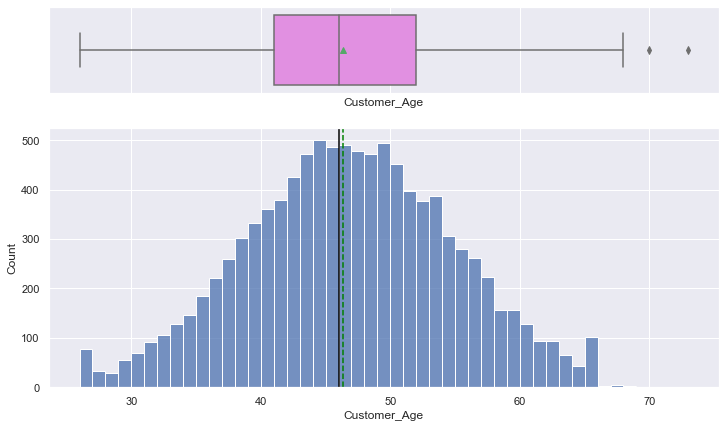

```python
histogram_boxplot(df, "Customer_Age", figsize=(12, 7), kde=False, bins=None)
```

#### Observations

- Customer age in this dataset hovers around middle age with the mid 50 percentile of customer falling between the ages of 41 and 52
- There are some outliers on the right end of the boxplot but we will not treat them as some variation is always expected in real-world scenarios for age - in this case, the max value for age in dataset is 73 which is reasonable

#### Dependent_count

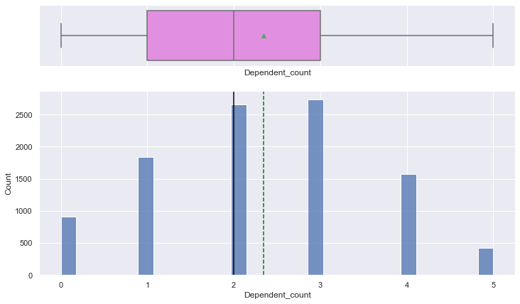

```python
histogram_boxplot(df, "Dependent_count", figsize=(12, 7), kde=False, bins=None)
```

#### Observations

- Distribution for Dependent_count looks to be slightly positively skewed with a mean of 2.35 and median of 2
- Outliers not observed

#### Months_on_book

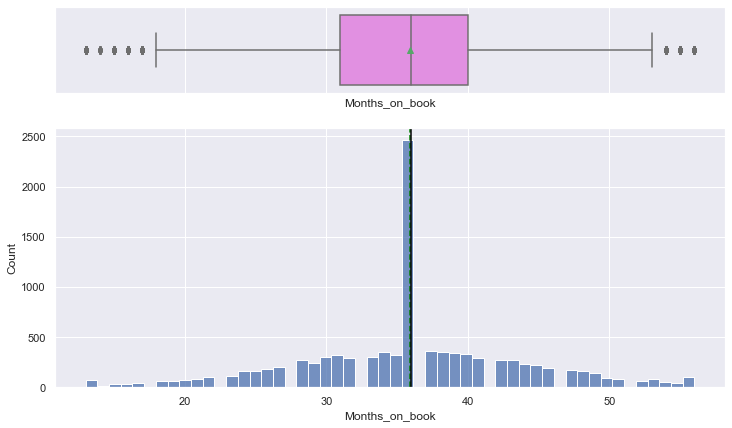

```python
histogram_boxplot(df, "Months_on_book", figsize=(12, 7), kde=False, bins=None)
```

#### Observations

- The mean and median period of relationship customers have had with bank is about 36 months
- Most customers fall in the 36-month mark
- We observe the presence of outliers which reflect expected real-world fluctuations in terms of period of relationship customers have with bank. Non-sensical or out of ordinary values not observed in this distribution

#### Total_Relationship_Count

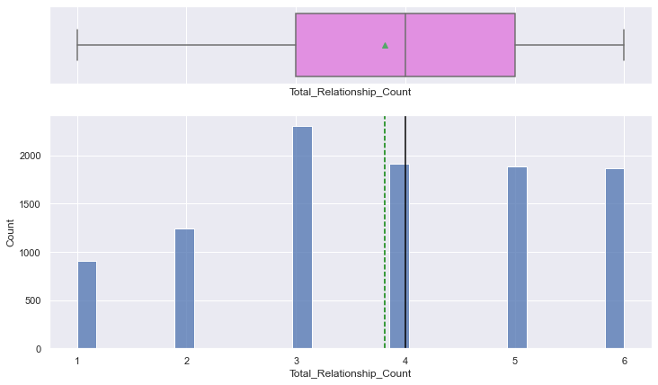

```python
histogram_boxplot(df, "Total_Relationship_Count", figsize=(12, 7), kde=False, bins=None)
```

#### Observations

- Customers tend to hold approximately 4 products from the bank on average - that is what the Total_Relationship_Count feature reflects
- We do not observe presence of outliers in the distribution

#### Months_Inactive_12_mon

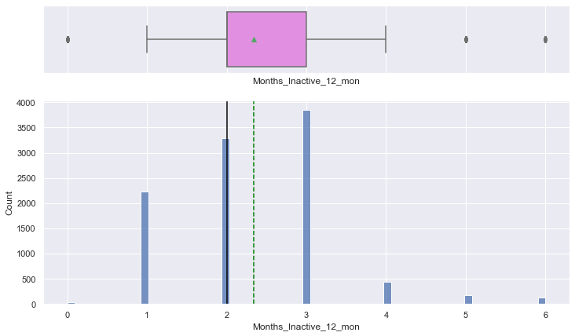

```python
histogram_boxplot(df, "Months_Inactive_12_mon", figsize=(12, 7), kde=False, bins=None)
```

#### Observations

- The mean months inactive over the last 12 for customers is approximately 2 months
- Although we observe presence of outliers, values in the distribution appear to reflect variation expected in a real-world scenario

#### Contacts_Count_12_mon

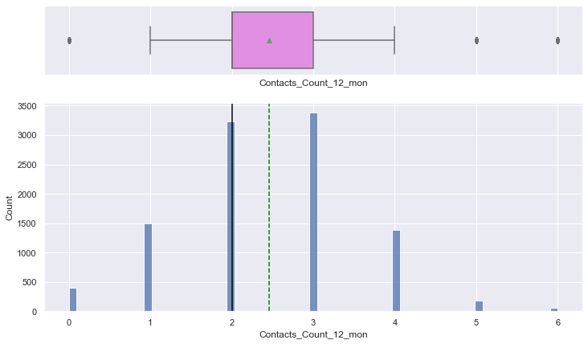

```python
histogram_boxplot(df, "Contacts_Count_12_mon", figsize=(12, 7), kde=False, bins=None)
```

#### Observations

- Number of contacts on average between bank and customer over the last 12 months is about 2.5
- Although we observe presence of outliers, values in the distribution appear to reflect variation expected in a real-world scenario

#### Credit_Limit

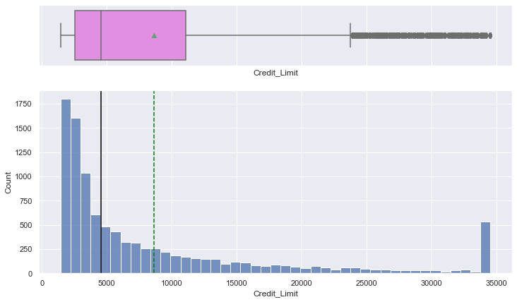

```python
histogram_boxplot(df, "Credit_Limit", figsize=(12, 7), kde=False, bins=None)
```

#### Observations

- In terms of credit card limit, we observe a highly positively skewed distribution with likely presence of outliers at the higher end of the distribution. Mean credit card limit of 8,631.95, median of 4,549.00
- We can see that there are some extreme observations in the variable that can be considered as outliers as they very far from the rest of the values.
- There are about 500 customers with credit limit at the high end creating an outlier cluster of values. Dropping these would mean a significant loss of data and capping would not resolve the issue as we would still end up with a cluster of values at the high end of the distribution. As such we will not remove or cap variable

#### Total_Revolving_Bal

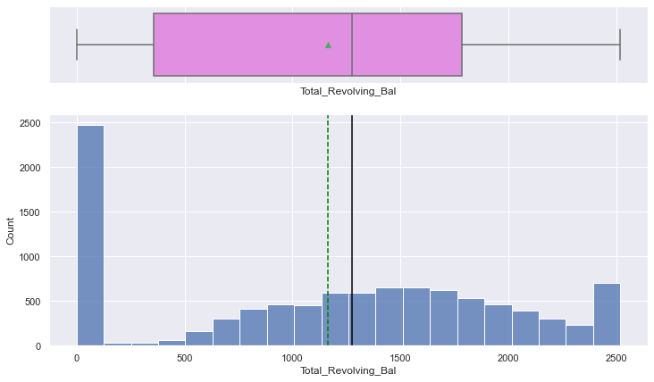

```python
histogram_boxplot(df, "Total_Revolving_Bal", figsize=(12, 7), kde=False, bins=None)
```

#### Observations

- In terms of the balance that carries over from one month to the next, Total_Revolving_Bal, we observe a slightly negatively skewed distribution, with median (1,276.00) greater than mean (1,162.81)
- We do not observe the presence of outliers in this distribution

#### Avg_Open_To_Buy

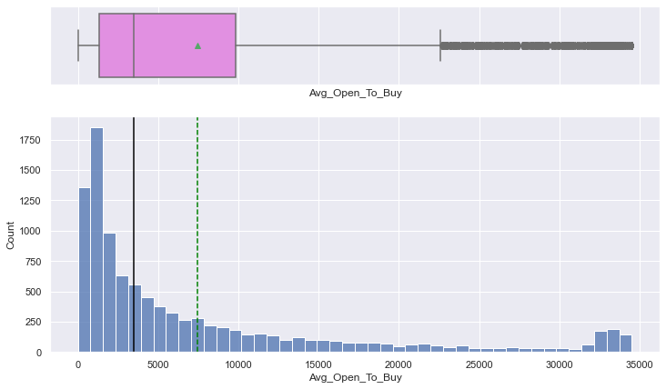

```python
histogram_boxplot(df, "Avg_Open_To_Buy", figsize=(12, 7), kde=False, bins=None)
```

#### Observations

- On average, customers have approximately 7,500 left on their limit to spend on their credit card - we also observe here a large discrepancy between median and max scores which indicates the presence of outliers in the distribution
- We observe the presence of outliers at the higher end of the distribution reflecting cluster of customers with higher credit limits - these customers would naturally have more money left over to spend in credit card accounts
- Dropping outliers would result in losing valuable data and capping would not resolve cluster issue leading to right-skewed distribution

#### Total_Amt_Chng_Q4_Q1

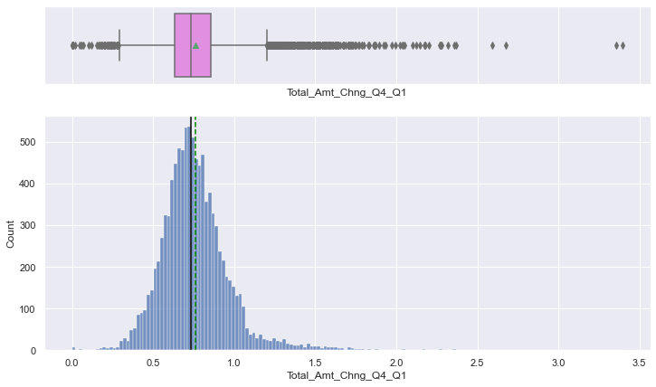

```python
histogram_boxplot(df, "Total_Amt_Chng_Q4_Q1", figsize=(12, 7), kde=False, bins=None)
```

#### Observations

- In terms of the ratio of the total transaction amount in 4th quarter and the total transaction amount in 1st quarter, we observe a mean ratio of 0.76 and 50% of mid-range scores falling between 0.63 and 0.86
- We observe outliers in both the lower and higher ends of the distribution
- Lower end outliers represent what we would expect - for some customers ratio of total transaction amount would correctly be 0
- Higher end outliers could be capped at next highest value to help narrow distribution and handle extreme values

```python
df[df["Total_Amt_Chng_Q4_Q1"] > 2.5]["Total_Amt_Chng_Q4_Q1"].nunique()
```

```
4
```

- Let's cap value at 2.5 to capture the most extreme values

```python
# Capping values for Total_Amt_Chng_Q4_Q1 at 2.5
df["Total_Amt_Chng_Q4_Q1"].clip(upper=2.5, inplace=True)
```

#### Total_Trans_Amt

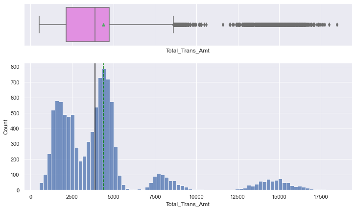

```python
histogram_boxplot(df, "Total_Trans_Amt", figsize=(12, 7), kde=False, bins=None)
```

#### Observations

- For total transaction amount over the previous 12 months we observe an average of 4,404.08 and median of 4,000
- Distribution is positively skewed with fluctuations clustering around $2000, $4000, $7800, and $15000
- Although distribution is skewed to the right, values observed are not unexpected in terms of real world financial transaction amounts over a 12-month period

#### Total_Trans_Ct

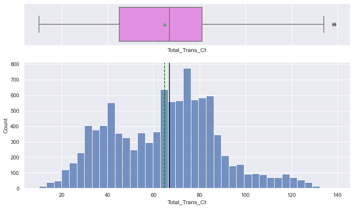

```python
histogram_boxplot(df, "Total_Trans_Ct", figsize=(12, 7), kde=False, bins=None)
```

#### Observations

- For count of total transactions over the previos 12 months, 50% mid range of the distribution falls between 45 and 81 transactions
- We observe two extreme high values which can be capped to bring them in allignment with the rest of the distribution - we will cap at Q3 + (1.5 * IQR)

```python
Q1 = df["Total_Trans_Ct"].quantile(0.25)  # 25th quantile
Q3 = df["Total_Trans_Ct"].quantile(0.75)  # 75th quantile
IQR = Q3 - Q1
Upper_Whisker = Q3 + 1.5 * IQR
```

```python
# Capping values for Total_Trans_Ct
df["Total_Trans_Ct"].clip(upper=Upper_Whisker, inplace=True)
```

#### Total_Ct_Chng_Q4_Q1

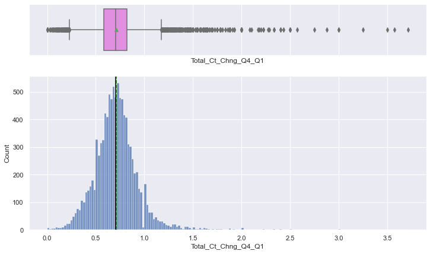

```python
histogram_boxplot(df, "Total_Ct_Chng_Q4_Q1", figsize=(12, 7), kde=False, bins=None)
```

#### Observations

- In terms of the ratio of the total transaction count in 4th quarter and the total transaction amount in 1st quarter, we observe a mean ratio of 0.71 and 50% of mid-range scores falling between 0.58 and 0.82
- Presence of outliers at the low and higher end of the distribution though at the higher end we observe more extreme values - we can cap those to help narrow the distribution

```python
df[df["Total_Ct_Chng_Q4_Q1"] > 2.5]["Total_Ct_Chng_Q4_Q1"].nunique()
```

```
8
```

- Let's cap value at 2.5 to capture the most extreme values

```python
# Capping values for Total_Ct_Chng_Q4_Q1 at 2.5
df["Total_Ct_Chng_Q4_Q1"].clip(upper=2.5, inplace=True)
```

#### Avg_Utilization_Ratio

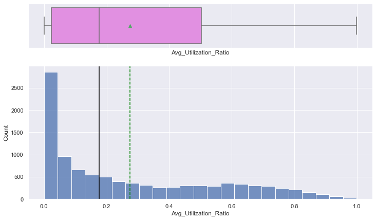

```python
histogram_boxplot(df, "Avg_Utilization_Ratio", figsize=(12, 7), kde=False, bins=None)
```

#### Observations

- Average Utilization Ratio represents how much of the available credit the customer spent and here we observe a mean of 0.27 with is greater than the median of the distribution, 0.18.
- Although we observe a long right tail in the distribution, no values falling outside of Q3 + 1.5*IQR observed

```python
# function to create labeled barplots


def labeled_barplot(data, feature, perc=False, n=None):
    """
    Barplot with percentage at the top

    data: dataframe
    feature: dataframe column
    perc: whether to display percentages instead of count (default is False)
    n: displays the top n category levels (default is None, i.e., display all levels)
    """

    total = len(data[feature])  # length of the column
    count = data[feature].nunique()
    if n is None:
        plt.figure(figsize=(count + 1, 5))
    else:
        plt.figure(figsize=(n + 1, 5))

    plt.xticks(rotation=90, fontsize=15)
    ax = sns.countplot(
        data=data,
        x=feature,
        palette="Paired",
        order=data[feature].value_counts().index[:n].sort_values(),
    )

    for p in ax.patches:
        if perc == True:
            label = "{:.1f}%".format(
                100 * p.get_height() / total
            )  # percentage of each class of the category
        else:
            label = p.get_height()  # count of each level of the category

        x = p.get_x() + p.get_width() / 2  # width of the plot
        y = p.get_height()  # height of the plot

        ax.annotate(
            label,
            (x, y),
            ha="center",
            va="center",
            size=12,
            xytext=(0, 5),
            textcoords="offset points",
        )  # annotate the percentage

    plt.show()  # show the plot
```

```python
def value_perc_dist(col):
    print("{}".format((df[col].value_counts()/df[col].count())*100))
```

#### Attrition_Flag

```python
value_perc_dist("Attrition_Flag")
```

```
Existing Customer   83.934
Attrited Customer   16.066
Name: Attrition_Flag, dtype: float64
```

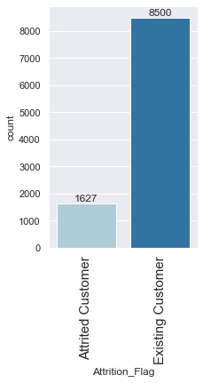

```python
labeled_barplot(df, "Attrition_Flag")
```

#### Observations

- Attrition_Flag is our dependent variable - the values of which we will attempt to predict
- "Attrited Customer" makes up about 16% of customers in this dataset

#### Gender

```python
value_perc_dist("Gender")
```

```
F   52.908
M   47.092
Name: Gender, dtype: float64
```

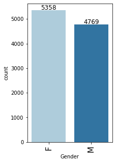

```python
labeled_barplot(df, "Gender")
```

#### Observations

- Most of the customers are female with close to 53% of total count

#### Education_Level

```python
value_perc_dist("Education_Level")
```

```
Graduate        36.338
High School     23.385
Uneducated      17.275
College         11.768
Post-Graduate    5.994
Doctorate        5.239
Name: Education_Level, dtype: float64
```

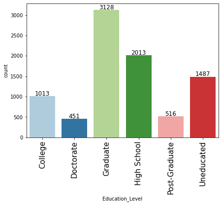

```python
labeled_barplot(df, "Education_Level")
```

#### Observations

- 36% of customers have graduate level education
- The next largest group are high school graduates with 23% followed by "Uneducated" with 17%

#### Marital_Status

```python
value_perc_dist("Marital_Status")
```

```
Married    49.979
Single     42.045
Divorced    7.976
Name: Marital_Status, dtype: float64
```

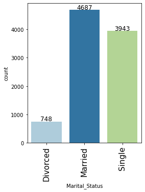

```python
labeled_barplot(df, "Marital_Status")
```

#### Observations

- About half of the customers in the dataset are married
- Single makes up the second largest group, 42% of customers

#### Income_Category

```python
value_perc_dist("Income_Category")
```

```
Less than $40K   39.501
$40K - $60K      19.856
$80K - $120K     17.027
$60K - $80K      15.552
$120K +           8.064
Name: Income_Category, dtype: float64
```

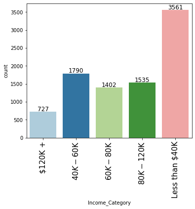

```python
labeled_barplot(df, "Income_Category")
```

#### Observations

- About 40% of customers fall in the Less than $40k income bracket
- The next largest group being customers with incomes between 40 and 60k

#### Card_Category

```python
value_perc_dist("Card_Category")
```

```
Blue       93.177
Silver      5.480
Gold        1.145
Platinum    0.197
Name: Card_Category, dtype: float64
```

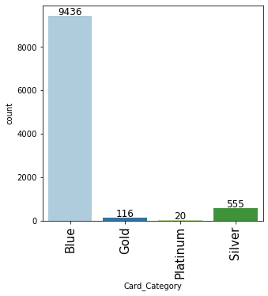

```python
labeled_barplot(df, "Card_Category")
```

#### Observations

- 93% of customers hold a Blue card, Silver is the second largest category with 5% of customers

### Bivariate Analysis

###### Encoding target variable "Attrition_Flag" to 0 for "Exixisting Customer" and 1 for "Attrited Customer", for the purpose of analysis.

```python
df["Attrition_Flag"].replace("Existing Customer", 0, inplace=True)
df["Attrition_Flag"].replace("Attrited Customer", 1, inplace=True)
```

```python
df["Attrition_Flag"] = df["Attrition_Flag"].astype(int)
```

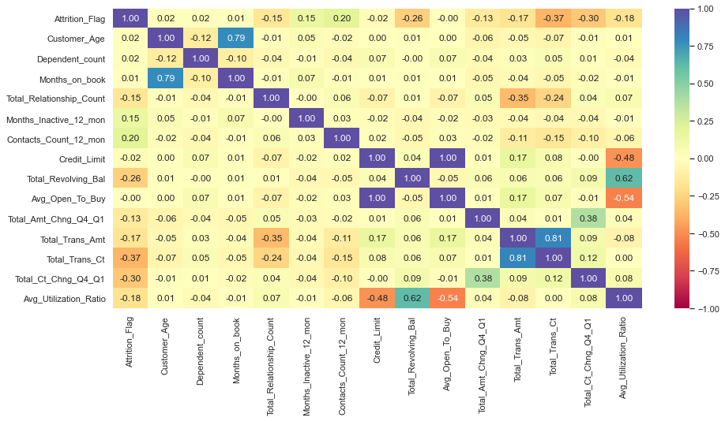

```python
plt.figure(figsize=(15, 7))
sns.heatmap(df.corr(), annot=True, vmin=-1, vmax=1, fmt=".2f", cmap="Spectral")
plt.show()
```

#### Observations

Positive correlations with customer attrition:

- Attrition_Flag and Contacts_Count_12_mon: we observe a slight positive correlation here (0.20) between customer attrition and number of contacts between the customer and bank over the previous 12 months
- Attrition_Flag and Months_Inactive_12_mon: we observe a slight positive correlation here (0.15) between customer attrition and customer inactivity over the previous 12 months

Negative correlations with customer attrition:

- Attrition_Flag and Total_Trans_Ct: we observe a negative correlation (the strongest correlation with the target variable) of -0.37 between total transaction count (i.e. total number of transactions) over the last 12 months and customer attrition.
- Attrition_Flag and Total_Ct_Chng_Q4_Q1: we observe a negative correlation, -0.30, between customer attrition and ratio of the total transaction count in 4th quarter to the total transaction count in 1st quarter
- Attrition_Flag and Total_Revolving_Bal: we observe a negative correlation of -0.26 between balance that carries over from month to month and customer attrition.
- Attrition_Flag and Avg_Utilization_Ratio: we observe a negative correlation, -0.18, between how much of the available credit the customer has spent and customer attrition.
- Attrition_Flag and Total_Trans_Amt: we observe a negative correlation, -0.17, between total transaction amount (last 12 months) and customer attrition.
- Attrition_Flag and Total_Relationship_Count: we observe a negative correlation, -0.15, between the total number of bank products used by customer and customer attrition.
- Attrition_Flag and Total_Amt_Chng_Q4_Q1: we observe a slightly negative correlation, -0.13, between customer attrition and ratio of the total transaction amount in 4th quarter to the total transaction amount in 1st quarter

```python
# function to plot stacked bar chart

def stacked_barplot(data, predictor, target):
    """
    Print the category counts and plot a stacked bar chart

    data: dataframe
    predictor: independent variable
    target: target variable
    """
    count = data[predictor].nunique()
    sorter = data[target].value_counts().index[-1]
    tab1 = pd.crosstab(data[predictor], data[target], margins=True).sort_values(
        by=sorter, ascending=False
    )
    print(tab1)
    print("-" * 120)
    tab = pd.crosstab(data[predictor], data[target], normalize="index").sort_values(
        by=sorter, ascending=False
    )
    tab.plot(kind="bar", stacked=True, figsize=(count + 1, 5))
    plt.legend(
        loc="lower left",
        frameon=False,
    )
    plt.legend(loc="upper left", bbox_to_anchor=(1, 1))
    plt.show()
```

###### Encoding target variable back to "Attrited Customer" (1) and "Exixisting Customer" (0), for the purpose of analysis.

```python
df["Attrition_Flag"].replace(0, "Existing Customer", inplace=True)
df["Attrition_Flag"].replace(1, "Attrited Customer", inplace=True)
```

```python
df["Attrition_Flag"] = df["Attrition_Flag"].astype("category")
```

```python
df.info()
```

```
<class 'pandas.core.frame.DataFrame'>
RangeIndex: 10127 entries, 0 to 10126
Data columns (total 20 columns):
 #   Column                    Non-Null Count  Dtype
---  ------                    --------------  -----
 0   Attrition_Flag            10127 non-null  category
 1   Customer_Age              10127 non-null  int64
 2   Gender                    10127 non-null  category
 3   Dependent_count           10127 non-null  int64
 4   Education_Level           8608 non-null   category
 5   Marital_Status            9378 non-null   category
 6   Income_Category           9015 non-null   category
 7   Card_Category             10127 non-null  category
 8   Months_on_book            10127 non-null  int64
 9   Total_Relationship_Count  10127 non-null  int64
 10  Months_Inactive_12_mon    10127 non-null  int64
 11  Contacts_Count_12_mon     10127 non-null  int64
 12  Credit_Limit              10127 non-null  float64
 13  Total_Revolving_Bal       10127 non-null  int64
 14  Avg_Open_To_Buy           10127 non-null  float64
 15  Total_Amt_Chng_Q4_Q1      10127 non-null  float64
 16  Total_Trans_Amt           10127 non-null  int64
 17  Total_Trans_Ct            10127 non-null  int64
 18  Total_Ct_Chng_Q4_Q1       10127 non-null  float64
 19  Avg_Utilization_Ratio     10127 non-null  float64
dtypes: category(6), float64(5), int64(9)
memory usage: 1.1 MB
```

#### Attrition_Flag vs Gender

```
Attrition_Flag  Attrited Customer  Existing Customer    All
Gender
All                          1627               8500  10127
F                             930               4428   5358
M                             697               4072   4769
------------------------------------------------------------------------------------------------------------------------
```

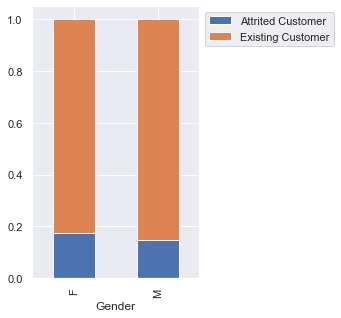

```python
stacked_barplot(df, "Gender", "Attrition_Flag")
```

#### Observations

- We observe a slightly greater proportion of attrited customers among female than male customers

#### Attrition_Flag vs Dependent_count

```
Attrition_Flag   Attrited Customer  Existing Customer    All
Dependent_count
All                           1627               8500  10127
3                              482               2250   2732
2                              417               2238   2655
1                              269               1569   1838
4                              260               1314   1574
0                              135                769    904
5                               64                360    424
------------------------------------------------------------------------------------------------------------------------
```

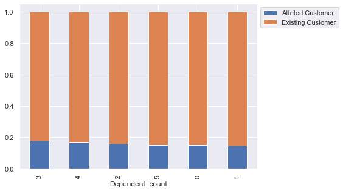

```python
stacked_barplot(df, "Dependent_count", "Attrition_Flag")
```

#### Attrition_Flag vs Education_Level

```
Attrition_Flag   Attrited Customer  Existing Customer   All
Education_Level
All                           1371               7237  8608
Graduate                       487               2641  3128
High School                    306               1707  2013
Uneducated                     237               1250  1487
College                        154                859  1013
Doctorate                       95                356   451
Post-Graduate                   92                424   516
------------------------------------------------------------------------------------------------------------------------
```

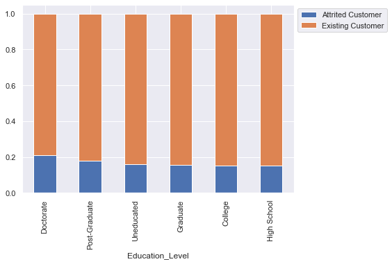

```python
stacked_barplot(df, "Education_Level", "Attrition_Flag")
```

#### Observations

- We observe higher proportion of attrited customers among those with doctorate and post-doctorate degrees

#### Attrition_Flag vs Marital_Status

```
Attrition_Flag  Attrited Customer  Existing Customer   All
Marital_Status
All                          1498               7880  9378
Married                       709               3978  4687
Single                        668               3275  3943
Divorced                      121                627   748
------------------------------------------------------------------------------------------------------------------------
```

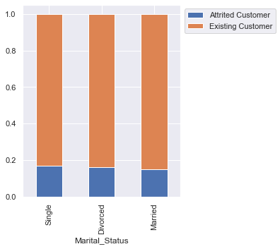

```python
stacked_barplot(df, "Marital_Status", "Attrition_Flag")
```

#### Observations

- We observe just a slightly lower proportion of attrited customers among customers who are married

#### Attrition_Flag vs Income_Category

```
Attrition_Flag   Attrited Customer  Existing Customer   All
Income_Category
All                           1440               7575  9015
Less than $40K                 612               2949  3561
$40K - $60K                    271               1519  1790
$80K - $120K                   242               1293  1535
$60K - $80K                    189               1213  1402
$120K +                        126                601   727
------------------------------------------------------------------------------------------------------------------------
```

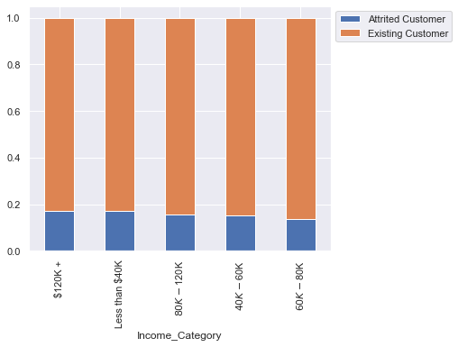

```python
stacked_barplot(df, "Income_Category", "Attrition_Flag")
```

#### Observations

- Attrited customers show up slightly more frequently among customers in the 120k+ income bracket and in the less than 40k bracket

#### Attrition_Flag vs Card_Category

```
Attrition_Flag  Attrited Customer  Existing Customer    All
Card_Category
All                          1627               8500  10127
Blue                         1519               7917   9436
Silver                         82                473    555
Gold                           21                 95    116
Platinum                        5                 15     20
------------------------------------------------------------------------------------------------------------------------
```

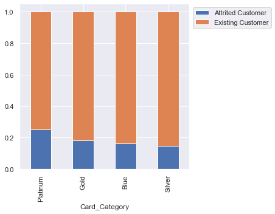

```python
stacked_barplot(df, "Card_Category", "Attrition_Flag")
```

#### Observations

- In total, there are only 20 Platinum customers in this dataset so it makes it hard to draw meaningful observations about this group
- Attrited customers appear in slightly greater proportion among Gold card customers in comparison to Blue and Silver

#### Attrition_Flag vs Total_Relationship_Count

```
Attrition_Flag            Attrited Customer  Existing Customer    All
Total_Relationship_Count
All                                    1627               8500  10127
3                                       400               1905   2305
2                                       346                897   1243
1                                       233                677    910
5                                       227               1664   1891
4                                       225               1687   1912
6                                       196               1670   1866
------------------------------------------------------------------------------------------------------------------------
```

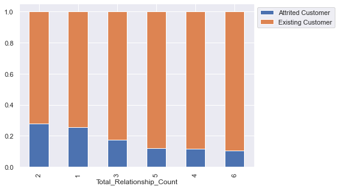

```python
stacked_barplot(df, "Total_Relationship_Count", "Attrition_Flag")
```

#### Observations

- Total_Relationship_Count and Customer Attrition: We observe that attrition happens in lower proportions among customers who hold more bank products

#### Attrition_Flag vs Months_Inactive_12_mon

```
Attrition_Flag          Attrited Customer  Existing Customer    All
Months_Inactive_12_mon
All                                  1627               8500  10127
3                                     826               3020   3846
2                                     505               2777   3282
4                                     130                305    435
1                                     100               2133   2233
5                                      32                146    178
6                                      19                105    124
0                                      15                 14     29
------------------------------------------------------------------------------------------------------------------------
```

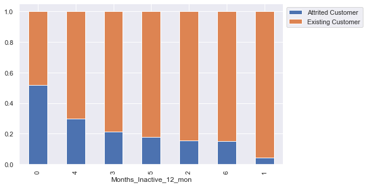

```python
stacked_barplot(df, "Months_Inactive_12_mon", "Attrition_Flag")
```

#### Attrition_Flag vs Contacts_Count_12_mon

```
Attrition_Flag         Attrited Customer  Existing Customer    All
Contacts_Count_12_mon
All                                 1627               8500  10127
3                                    681               2699   3380
2                                    403               2824   3227
4                                    315               1077   1392
1                                    108               1391   1499
5                                     59                117    176
6                                     54                  0     54
0                                      7                392    399
------------------------------------------------------------------------------------------------------------------------
```

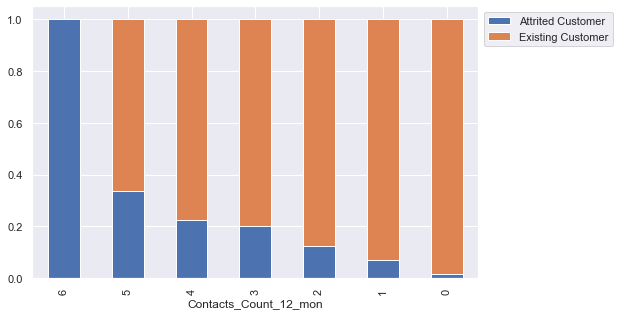

```python
stacked_barplot(df, "Contacts_Count_12_mon", "Attrition_Flag")
```

#### Observations

- Customers in contact with the bank 6 times attrited 100%
- Pattern of higher number of contacts, higher attrition follows what it looks like a linear pattern, increasing attrition as number of contacts increases (or vice-versa)

#### Attrition_Flag vs Customer_Age

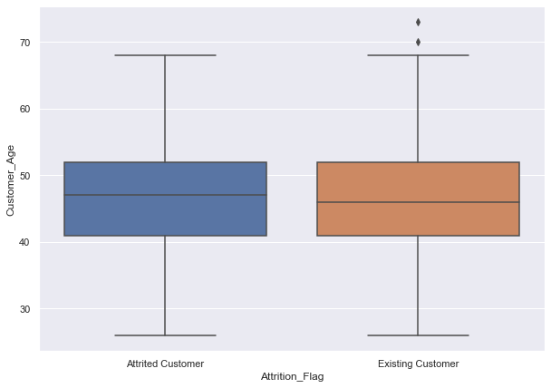

```python
sns.set(rc={"figure.figsize": (10, 7)})
sns.boxplot(x="Attrition_Flag", y="Customer_Age", data=df, orient="vertical")
```

#### Observations

- We observe very similar distributions between attrited and existing customers in terms of age
- The median age for attrited customers being a little greater than for existing customers indicating a slight bent towards older customers in the attrited group

#### Attrition_Flag vs Months_on_book

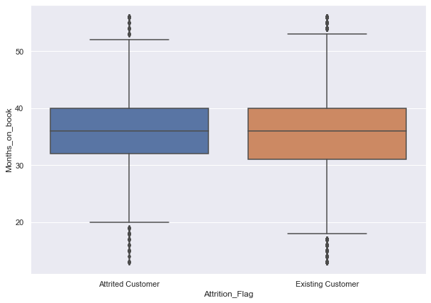

```python
sns.set(rc={"figure.figsize": (10, 7)})
sns.boxplot(x="Attrition_Flag", y="Months_on_book", data=df, orient="vertical")
```